# 14. Applications of Mutivariable Functions

Cheng Peng

West Chester University

# 1 General Review and Exercises

- **Basic Rules and Properties of Integrals**.

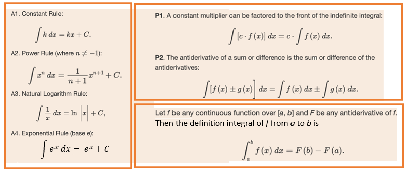

- **Notations of Differentials**

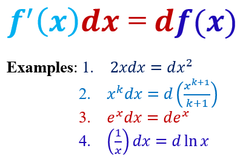

The last example assumes that $x > 0$.

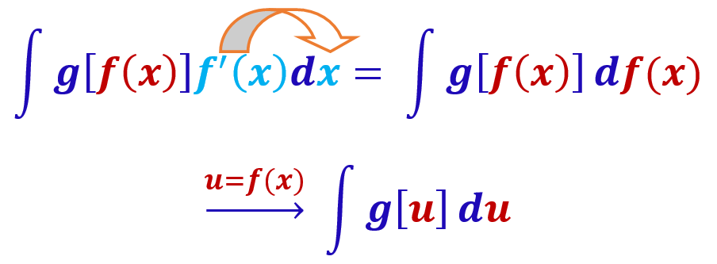

# 2 More on Partial Derivatives

We first work on two examples of finding the partial derivatives of functions with multiple variables to review the steps and the relevant rules. Then present a pictorial interpretation of partial derivative.

## 2.1 Examples

Recall that when taking the derivative of a multivariable function with respect to one variable, all other variables are treated as constant scalars.

**Example 1**: Find all first order partial derivatives of function $f(x,y,z) = x^2y^3z^4$

**Solution**: The derivative rule of scalar multiplication will be used repeatedly in the following.

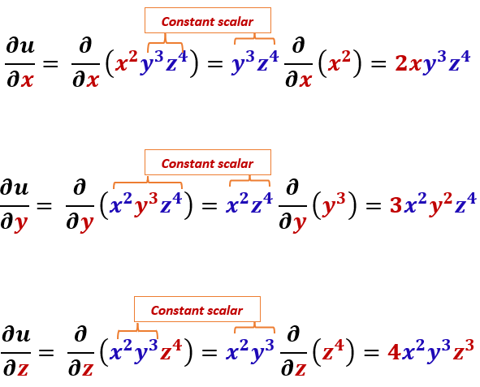

**Example 2**: Let $g(x,y) = \ln(x^2 + xy^4)$. Find partial derivative $g_x(x,y)$ and $g_y(x,y)$.

**Solution**: We do the first part. $g_y$ is used for practice.

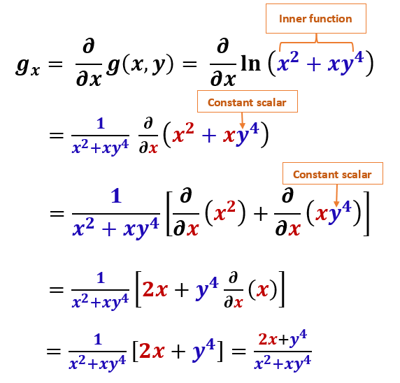

## 2.2 Geometry of Partial Derivatives

The derivative of a single variable function is the slope of the tangent line at $x$. Similarly, a partial derivative also represents the slope of a curve on the surface of the underlying function. The following figure shows the geometry of partial derivatives.

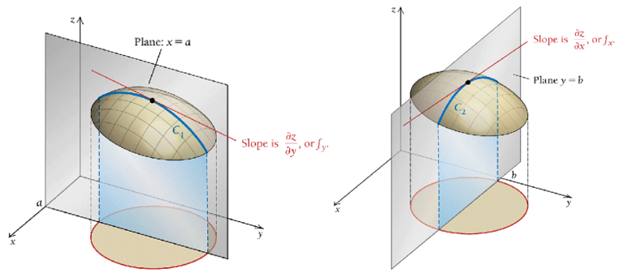

**Example 3**: Consider the partial derivative $\partial f / \partial x$ of function $f(x,y) = x^2 + y^2$ at $(x_0, y_0)$.

**Solution**. By definition, the partial derivative of $f(x,y)$ with respect to $x$ is given by
$$\frac{\partial f(x,y)}{\partial x} = \frac{\partial}{\partial x}(x^2 +
y^2) = \frac{\partial}{\partial x}(x^2) + \frac{\partial}{\partial
x}(y^2)\stackrel{\text{y is a constant}}{=} 2x + 0 = 2x.$$

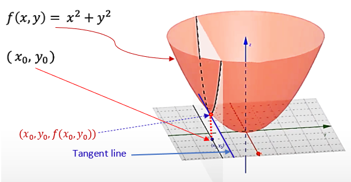

# 3 Business Applications - Marginal Productivity

One model of production that is frequently in business and economics is the Cobb-Douglass production function
$$p(x,y) = Ax^\alpha y^{1-\alpha}~~\text{for}~~~A>0 ~~~\text{and}~~~
0<\alpha < 1.$$
where $p(x,y)$ is the number of units produced with $x$ units of labor and $y$ units of capital (Capital is the cost of machinery, buildings, tools, and supplies). The partial derivatives

$$\frac{\partial p(x,y)}{\partial x}~~~\text{and}~~~\frac{\partial
p(x,y)}{\partial y}$$
are called, respectively, the **marginal productivity of labor** and the **marginal productivity of capital**.

**Remark**: *$\alpha$ is a system parameter determined by the production process based on historical production data. It could also be controlled by the management.*

1). Find the number of units produced with 125 units of labor and 64 units of capital.

2). Find the **marginal productivity**.

3). Evaluate the **marginal productivity** at $x=125$ and $y = 64$.

(2). We first find the marginal productivity functions of labor and capital respectively in the following.

(3). We evaluate the above two partial derivatives respectively in the following